# regression_analysis

2023-04-07

# Data Prep

First, lets bring in some packages.

```r
library(corrplot)
library(xts)
library(vctrs)
library(rlang)
library(kernlab)
library(crypto2)
library('lubridate')
library('dplyr')
library(reshape2)
library(glue)
library(qcc)
library(tidyverse)
library(data.table)
library(ggplot2)
library(DAAG)
library(caTools)
library(car)
library(quantmod)
library(MASS)
library(corrplot)
library(caret)
library(RcppRoll)
library(Rcpp)
```

Now bring in the data:

```r
data.daily <- read.csv('../Data/data_daily.csv')[,-1]
data.hourly <- read.csv('../Data/data_hourly.csv')[,-1]
```

Next, lets drop the rows that have no information in the close column (due to the missing price data in the twitter input data. This was addressed in the data prep Rmd file.)

```r
data.hourly <-data.hourly[is.na(data.hourly$close) == F,]

data.hourly$datetime <- ymd_hms(data.hourly$datetime)
data.hourly$day <- ymd(data.hourly$day)

data.daily$day <- ymd(data.daily$day)
```

# Helper Functions

Next, as we did in our data exploration workbook, lets create a function that allows us to shift the close price *forward* n periods. That way, when we look at one row of data, we can say that the comment/tweet activity at time *t-n* is being compared against the closing price at time *t*.

```r
shift_df <- function(df, n){
  dfc <- data.table(copy(df))
  cols = c("close")
  anscols = paste("lead", cols, sep="_")

  dfc[order(day), (anscols) := shift(.SD, n, type="lead"), .SDcols=cols]
  dfc <- dfc %>% mutate(price_dif = lead_close - close)
  dfc <- dfc %>% mutate(price_dif_percent = round((lead_close/close) - 1,4))
  dfc <- dfc %>% mutate(price_dir = ifelse(price_dif >=0, 1,0))
  dfc <- dfc[1:(nrow(dfc)-n),]
  dfc

}
```

Now, we want to also aggregate hour independent data points back *d* amount of days. This allows us to answer the following: How does the sentiment over the last *d* days/hours impact the price of Bitcoin *n* days/hours from now?

Lets write another function that can do this transformation for us.

```r
agg_lag_df <- function(df, d){

  cols <- colnames(df)
  cols <- cols[! cols %in% c('close','lead_close')]
  e <- nrow(df)
  print(e)
  for (c in cols){
  vname <- glue('{c}')
    df <- df %>%

        mutate( !!vname := roll_sum(.data[[c]], d, align = "right", fill = NA))
  }

  df <- df[d + 1:(e-d),]
  df
}
```

Since we are going to want to test different lag/lead times to see if there is any difference in model performance, lets build another function that takes in:

- The initial data frame (daily/hourly)
- A formula
- A list of intervals we want to test

```r
run_intervals <- function(df, form, N, response_var){

  for (n in N){
    mdf <- shift_df(df, n)
    m <- lm(formula(form), mdf)

    print(n)
    print(validate_model(mdf, m, response_var))
  }

}
```

# Linear Regression Models

Below, we will build a series of models and evaluate each of them under the below assumptions:

Our model above failed to consider the assumptions of a linear model. These are:

1. Collinearity
2. Non-linearity of the response-predictor relationships (addressed in eda.Rmd)
3. Correlation of error terms
4. Non-constant variance of error terms
5. Outliers
6. High-leverage points

We will address each of these as we move through this documentation.

## Simple Linear-Linear Model

For our first model, we are going to look at only the features that we saw were strongly correlated with the price movements of Bitcoin.

```r
df.daily <- shift_df(data.daily, 1)[,c('lead_close',
           #'close',
           'total_reddit',
           'positive_reddit',
           'neutral_reddit',
           'negative_reddit',
           'total_tweets',
           'positive_tweets',
           'neutral_tweets',
           'negative_tweets')] %>% agg_lag_df(7)
```

```
## [1] 538
```

```r
daily.lin_lin <- lm(lead_close ~ ., data = df.daily)
summary(daily.lin_lin)
```

```
##
## Call:
## lm(formula = lead_close ~ ., data = df.daily)
##
## Residuals:
##     Min      1Q  Median      3Q     Max
## -3949.0  -921.5   -89.2   793.3  6187.4
##
## Coefficients: (1 not defined because of singularities)
##                   Estimate Std. Error t value Pr(>|t|)
## (Intercept)     1043.47074  244.47835   4.268 2.34e-05 ***
## total_reddit      -1.88646    0.17773 -10.614  < 2e-16 ***
## positive_reddit    2.51602    0.26383   9.537  < 2e-16 ***
## neutral_reddit     3.14762    0.23916  13.161  < 2e-16 ***
## negative_reddit         NA         NA      NA       NA
## total_tweets       0.07380    0.01116   6.613 9.30e-11 ***
## positive_tweets    0.03548    0.01673   2.121   0.0344 *
## neutral_tweets    -0.11444    0.01487  -7.696 7.06e-14 ***
## negative_tweets   -0.11008    0.01451  -7.589 1.49e-13 ***
## ---
## Signif. codes:  0 '***' 0.001 '**' 0.01 '*' 0.05 '.' 0.1 ' ' 1
##
## Residual standard error: 1356 on 523 degrees of freedom
## Multiple R-squared:  0.8204, Adjusted R-squared:  0.818
## F-statistic: 341.3 on 7 and 523 DF,  p-value: < 2.2e-16
```

```r
validate_model <- function(df, model){

    sample_size <- floor(.8 * nrow(df))

    train <-df[1:sample_size,]
    test <- df[(sample_size +1) :nrow(df),]



    m <- cv.lm(df, model, m=5, seed=10, printit=F, plotit =F)
    response_var <- summary(model)$call$formula[[2]]
    SSres <- attr(m,"ms")*nrow(df)
    SStotal <- sum((df[[response_var]] - mean(df[[response_var]]))^2)
    rs <- 1- SSres/SStotal
    rs

}

t <- validate_model(df.daily, daily.lin_lin)
t
```

```
## [1] 0.8132937
```

```r
df.daily <- shift_df(data.daily, 1)[,c('lead_close',
           'positive_reddit',
           'neutral_reddit',
           'negative_reddit',
           'positive_tweets',
           'neutral_tweets',
           'negative_tweets')] %>% agg_lag_df(7)
```

```
## [1] 538
```

```r
daily.lin_lin <- lm(lead_close ~ ., data = df.daily)
summary(daily.lin_lin)
```

```
##
## Call:
## lm(formula = lead_close ~ ., data = df.daily)
##
## Residuals:
##     Min      1Q  Median      3Q     Max
## -4216.6  -920.3   -16.0   755.2  6550.3
##
## Coefficients:
##                   Estimate Std. Error t value Pr(>|t|)
## (Intercept)      2.101e+03  1.923e+02  10.930  < 2e-16 ***
## positive_reddit  2.572e-01  7.977e-02   3.224  0.00134 **
## neutral_reddit   1.600e+00  1.468e-01  10.895  < 2e-16 ***
## negative_reddit -1.384e+00  1.671e-01  -8.282 1.02e-15 ***
## positive_tweets  1.288e-01  9.355e-03  13.763  < 2e-16 ***
## neutral_tweets  -2.318e-02  5.762e-03  -4.023 6.61e-05 ***
## negative_tweets -6.638e-02  1.343e-02  -4.943 1.04e-06 ***
## ---
## Signif. codes:  0 '***' 0.001 '**' 0.01 '*' 0.05 '.' 0.1 ' ' 1
##
## Residual standard error: 1410 on 524 degrees of freedom
## Multiple R-squared:  0.8054, Adjusted R-squared:  0.8032
## F-statistic: 361.4 on 6 and 524 DF,  p-value: < 2.2e-16
```

```r
vif(daily.lin_lin)
```

```
## positive_reddit  neutral_reddit negative_reddit positive_tweets  neutral_tweets
##       109.14183        37.62567       112.11584        23.55250        13.59926
## negative_tweets
##        18.53838
```

```r
validate_model(df.daily,daily.lin_lin)
```

```
## [1] 0.798213
```

```r
attributes(daily.lin_lin$model)$terms[1]$
daily.lin_lin$call
```

```r
formula(daily.lin_lin)
```

```
## lead_close ~ positive_reddit + neutral_reddit + negative_reddit +
##     positive_tweets + neutral_tweets + negative_tweets
```

### Collinearity

The first assumption we will address is collinearity. That is, the assumption that our predictor variables are correlated to one another. Intuitively, we can assume that they are correlated. The features we are using are the total tweets which is just the total of the positive, negative, and neutral tweets, and for Reddit, the total comments This is why our validated model through the error:

```
Warning: prediction from a rank-deficient fit may be misleading
```

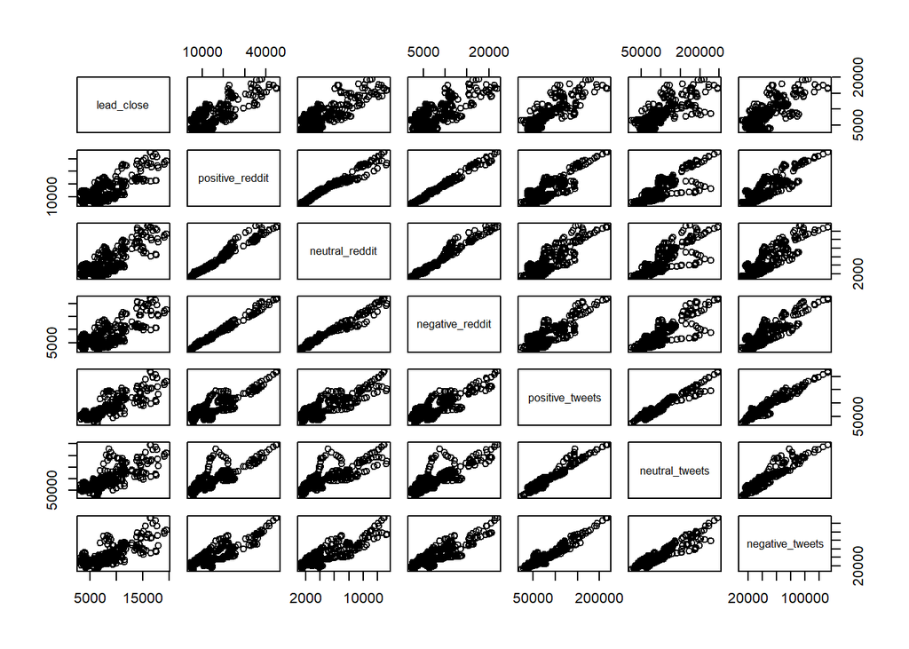

```r
plot(df.daily)
```

Visually inspecting this, we can see that multicolinearity is very strong across all of our predictor variables.

Lets first attempt to just remove the total columns, as they are just a combination of the others.

```r
df.daily <- shift_df(data.daily, 1)[,c('lead_close',
           'positive_reddit',
           'neutral_reddit',
           'negative_reddit',
           'positive_tweets',
           'neutral_tweets',
           'negative_tweets')] %>% agg_lag_df(7)
```

```
## [1] 538
```

```r
daily.lin_lin <- lm(lead_close ~ ., data = df.daily)
summary(daily.lin_lin)
```

```
##
## Call:
## lm(formula = lead_close ~ ., data = df.daily)
##
## Residuals:
##     Min      1Q  Median      3Q     Max
## -4216.6  -920.3   -16.0   755.2  6550.3
##
## Coefficients:
##                   Estimate Std. Error t value Pr(>|t|)
## (Intercept)      2.101e+03  1.923e+02  10.930  < 2e-16 ***
## positive_reddit  2.572e-01  7.977e-02   3.224  0.00134 **
## neutral_reddit   1.600e+00  1.468e-01  10.895  < 2e-16 ***
## negative_reddit -1.384e+00  1.671e-01  -8.282 1.02e-15 ***
## positive_tweets  1.288e-01  9.355e-03  13.763  < 2e-16 ***
## neutral_tweets  -2.318e-02  5.762e-03  -4.023 6.61e-05 ***
## negative_tweets -6.638e-02  1.343e-02  -4.943 1.04e-06 ***
## ---
## Signif. codes:  0 '***' 0.001 '**' 0.01 '*' 0.05 '.' 0.1 ' ' 1
##
## Residual standard error: 1410 on 524 degrees of freedom
## Multiple R-squared:  0.8054, Adjusted R-squared:  0.8032
## F-statistic: 361.4 on 6 and 524 DF,  p-value: < 2.2e-16
```

```r
vif(daily.lin_lin)
```

```
## positive_reddit  neutral_reddit negative_reddit positive_tweets  neutral_tweets
##       109.14183        37.62567       112.11584        23.55250        13.59926
## negative_tweets
##        18.53838
```

```r
validate_model(df.daily,daily.lin_lin)
```

```
## [1] 0.798213
```

We have a couple of options here.

1. Keep only one term, at random
2. Add interaction terms
3. Principal Component Analysis

In this exploration, we will try the latter two.

## Interaction Term

For this model, we will try using an interaction term.

For our interaction term, we will use the volume traded at period *t-n*. Logically, the amount price moves may be tied to not just how much people are talking about bitcoin, but also how is being traded. For example, people may be talking very negatively about bitcoin at a given moment, but what if no one is trading on this information?

```r
df.daily <- df.daily <- shift_df(data.daily, 1)[,c('lead_close',
           'volume',
           'positive_reddit',
           'neutral_reddit',
           'negative_reddit',
           'positive_tweets',
           'neutral_tweets',
           'negative_tweets')] %>% agg_lag_df(7)
```

```
## [1] 538
```

```r
 daily.lin_lin.m2 <- lm(lead_close ~
                         positive_reddit*volume +
                         negative_reddit*volume +
                         neutral_reddit*volume  +
                         positive_tweets*volume +
                         neutral_reddit*volume +
                         negative_tweets*volume, data = df.daily)
 summary(daily.lin_lin.m2)
```

```
##
## Call:
## lm(formula = lead_close ~ positive_reddit * volume + negative_reddit *
##     volume + neutral_reddit * volume + positive_tweets * volume +
##     neutral_reddit * volume + negative_tweets * volume, data = df.daily)
##
## Residuals:
##     Min      1Q  Median      3Q     Max
## -3308.5  -618.7   161.0   715.8  4685.6
##
## Coefficients:
##                          Estimate Std. Error t value Pr(>|t|)
## (Intercept)             2.678e+03  3.768e+02   7.107 3.95e-12 ***
## positive_reddit        -2.739e-01  1.385e-01  -1.978 0.048420 *
## volume                  2.513e-08  9.538e-09   2.635 0.008667 **
## negative_reddit        -6.984e-01  2.862e-01  -2.440 0.015019 *
## neutral_reddit          1.854e+00  3.283e-01   5.646 2.71e-08 ***
## positive_tweets         5.942e-02  1.433e-02   4.145 3.96e-05 ***
## negative_tweets        -7.424e-03  2.340e-02  -0.317 0.751175
## positive_reddit:volume  9.349e-12  1.930e-12   4.843 1.69e-06 ***
## volume:negative_reddit -2.773e-12  3.718e-12  -0.746 0.456055
## volume:neutral_reddit  -1.444e-11  3.780e-12  -3.821 0.000149 ***
## volume:positive_tweets  8.565e-13  3.704e-13   2.312 0.021151 *
## volume:negative_tweets -2.428e-12  5.326e-13  -4.559 6.41e-06 ***
## ---
## Signif. codes:  0 '***' 0.001 '**' 0.01 '*' 0.05 '.' 0.1 ' ' 1
##
## Residual standard error: 1154 on 519 degrees of freedom
## Multiple R-squared:  0.8709, Adjusted R-squared:  0.8681
## F-statistic: 318.2 on 11 and 519 DF,  p-value: < 2.2e-16
```

### Collinearity

```r
vif(daily.lin_lin.m2)
```

```
## there are higher-order terms (interactions) in this model
## consider setting type = 'predictor'; see ?vif
```

```
##        positive_reddit                 volume        negative_reddit
##              490.87119               21.27269              491.03849
##         neutral_reddit        positive_tweets        negative_tweets
##              280.81370               82.53693               83.99857
## positive_reddit:volume volume:negative_reddit  volume:neutral_reddit
##             1108.32056              996.78261              451.89887
## volume:positive_tweets volume:negative_tweets
##              837.84948              610.74017
```

## Principal Component Analysis

Now, we will instead try to reduce the number of variables by using prinicipal component analysis. This will take all of our features, make a linear combination of them, and give us a new set of features.

**Note:** PCA is outside of the scope of this assignment, so no further explanation will be delivered.

```r
# build a df with all columns, exluding the columns discussed above like total_comments, and the columns relating to bitcoin price.


df.daily.all <- shift_df(data.daily, 1)[,c('lead_close',
           'volume',
           'positive_reddit',
           'neutral_reddit',
           'negative_reddit',
           'positive_tweets',
           'neutral_tweets',
           'negative_tweets')]  %>% agg_lag_df(7)
```

```
## [1] 538
```

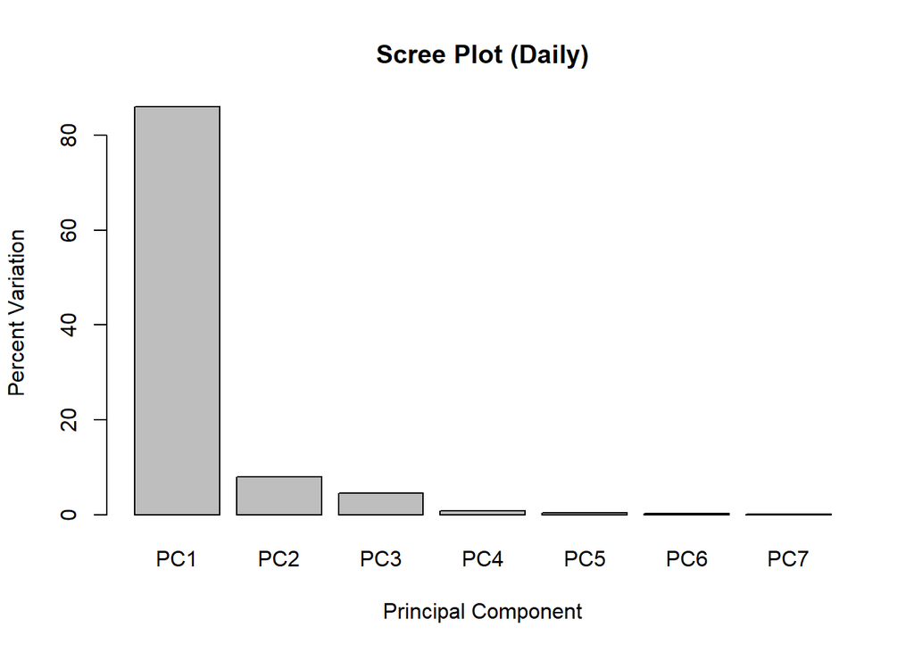

```r
#replace na's with 0
df.daily.all <- mutate_all(df.daily.all, ~replace_na(.,0))

#perform PCA
df.daily.all.pca <- prcomp(~.,df.daily.all[,!'lead_close'], scale = TRUE)



#scree plot
pca.var.per <- round(summary(df.daily.all.pca)$importance[2,]*100,1)
barplot(pca.var.per,
         main ="Scree Plot (Daily)",
         xlab= "Principal Component",
         ylab = "Percent Variation")
```

```r
df.daily.all.pca.3 <- as.data.frame(cbind(df.daily.all.pca$x[,1:3],
                                      df.daily.all[,'lead_close']))

daily.lin_lin.pca <- lm(lead_close~. ,
                        data = df.daily.all.pca.3)

summary(daily.lin_lin.pca)
```

```
##
## Call:
## lm(formula = lead_close ~ ., data = df.daily.all.pca.3)
##
## Residuals:
##     Min      1Q  Median      3Q     Max
## -4662.5  -658.3   348.5   910.7  6841.3
##
## Coefficients:
##             Estimate Std. Error t value Pr(>|t|)
## (Intercept)  7411.93      67.08 110.492  < 2e-16 ***
## PC1          1065.32      27.36  38.939  < 2e-16 ***
## PC2         -1211.77      90.22 -13.431  < 2e-16 ***
## PC3           475.35     118.38   4.015 6.79e-05 ***
## ---
## Signif. codes:  0 '***' 0.001 '**' 0.01 '*' 0.05 '.' 0.1 ' ' 1
##
## Residual standard error: 1546 on 527 degrees of freedom
## Multiple R-squared:  0.7647, Adjusted R-squared:  0.7634
## F-statistic: 570.9 on 3 and 527 DF,  p-value: < 2.2e-16
```

```r
print('VIF:')
```

```
## [1] "VIF:"
```

```r
vif(daily.lin_lin.pca)
```

```
## PC1 PC2 PC3
##   1   1   1
```

```r
validate_model(df.daily.all.pca.3,daily.lin_lin.pca)
```

```
## [1] 0.7585607
```

```r
validate_model(df.daily.all.pca.3,daily.lin_lin.pca)
```

```
## [1] 0.7585607
```

#### Correlation of error terms

An important assumption is that error terms e1, e2, ...,en are uncorrelated. If they aren’t, then we have autocorrelation. To check this, we will perform a Durbin Watson Test.

```r
durbinWatsonTest(daily.lin_lin.pca)
```

```
##  lag Autocorrelation D-W Statistic p-value
##    1       0.9341648     0.1255192       0
##  Alternative hypothesis: rho != 0
```

Our p value is 0, which means we can reject the null hypothesis and conclude that the residuals in this regression model are autocorrelated.

Why is this? Durbin- Watson statistic is only suitable for ordered time or spatial series. Because we transformed our data into cross section variables with PCA, we cannot use it to detect autocorrelation. https://journals.plos.org/plosone/article/file?id=10.1371/journal.pone.0146865&type=printable

Citation: Chen Y (2016) Spatial Autocorrelation Approaches to Testing Residuals from Least Squares Regression. PLoS ONE 11(1): e0146865. doi:10.1371/journal.pone.0146865

The impact of autocorrelation on PCA and PCA-based SPC is neither well understood nor properly documented. As such, for the purposes of this paper, we will ignore this assumption.

https://onlinelibrary.wiley.com/doi/full/10.1002/qre.1858

Vanhatalo, E., and Kulahci, M. (2016) Impact of Autocorrelation on Principal Components and Their Use in Statistical Process Control. *Qual. Reliab. Engng. Int.*, 32: 1483– 1500. doi: 10.1002/qre.1858.

#### Heteroskedasticity (non-constant variance of error terms)

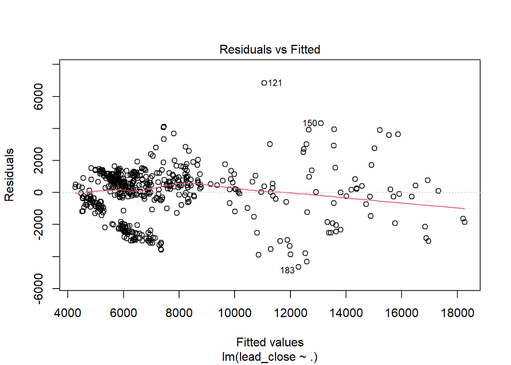

```r
plot(daily.lin_lin.pca, which=1)
```

In addition to heteroskedacity, we also want to check and see if our residuals are normally distirubted and if they are spread equally along the range of fitted values.

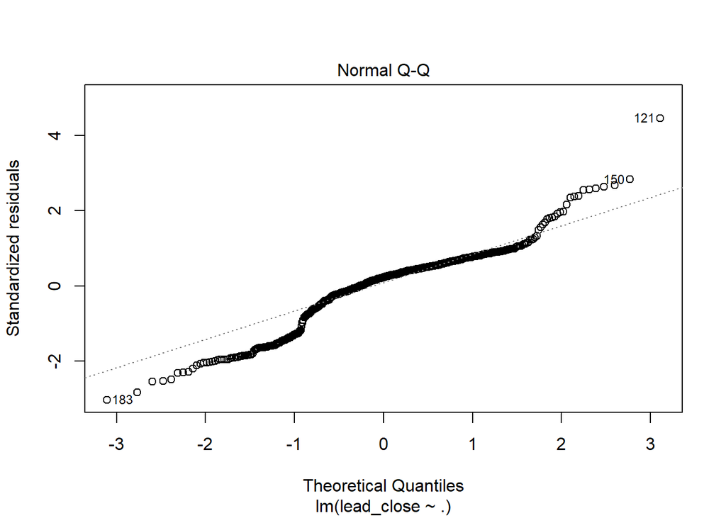

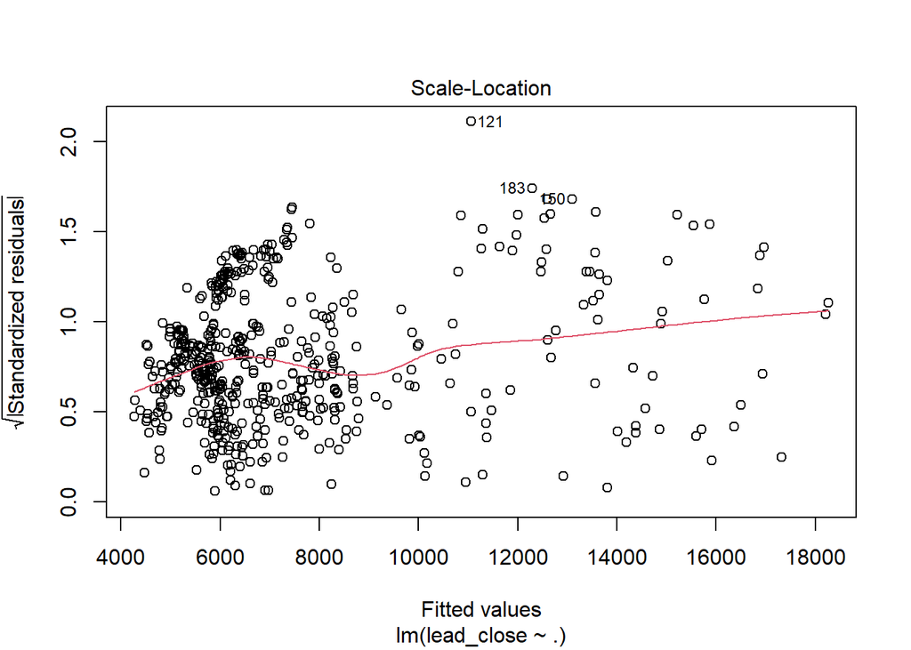

```r
plot(daily.lin_lin.pca, which=c(2, 3))
```

#### Outliers and High Leverage Points

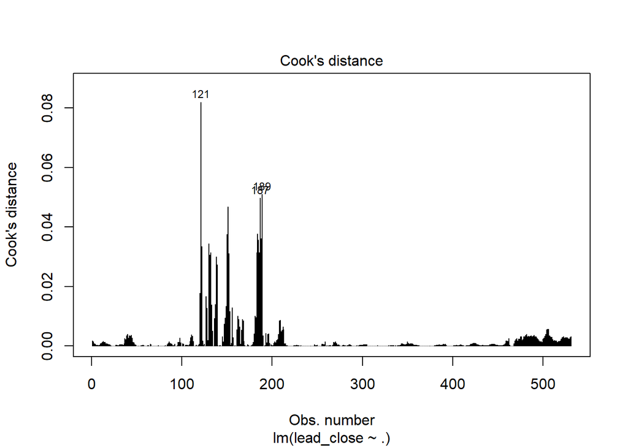

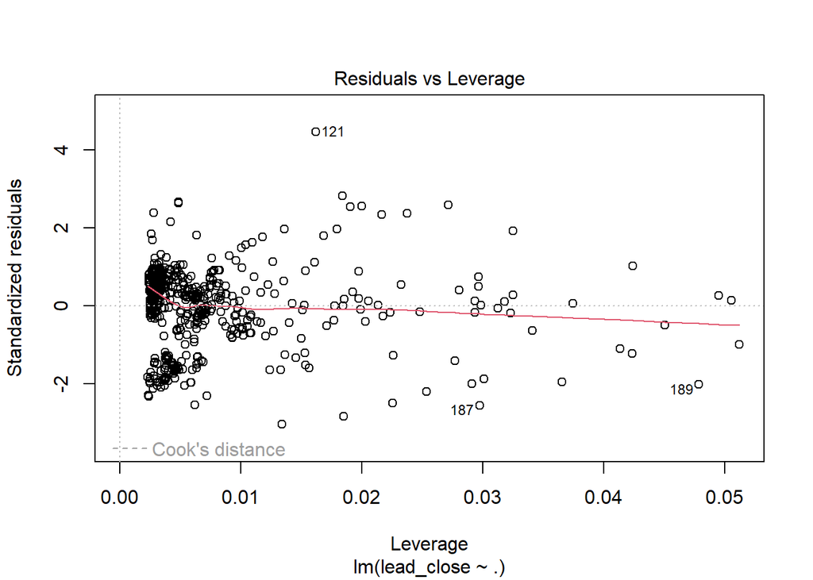

```r
plot(daily.lin_lin.pca, which=c(4, 5))
```

## Simple linear Model- Less Variables

In this model, we will attempt a very simple model, removing most of the variables in attempt to reduce collinearity and see if it holds up to other assumptions.

```r
df.daily.all <- shift_df(data.daily, 1)[,c('lead_close',
           'volume',
           'total_reddit',
           'total_tweets')] %>% agg_lag_df(7)
```

```
## [1] 538
```

```r
total_models <- lm(lead_close ~ volume +total_reddit+ total_tweets, df.daily.all)
vif(total_models)
```

```
##       volume total_reddit total_tweets
##     2.153811     3.513143     4.622891
```

```r
summary(total_models)
```

```
##
## Call:
## lm(formula = lead_close ~ volume + total_reddit + total_tweets,
##     data = df.daily.all)
##
## Residuals:
##     Min      1Q  Median      3Q     Max
## -4415.5  -734.0   320.0   940.7  6834.0
##
## Coefficients:
##               Estimate Std. Error t value Pr(>|t|)
## (Intercept)  1.666e+03  1.812e+02   9.193  < 2e-16 ***
## volume       6.525e-08  3.985e-09  16.374  < 2e-16 ***
## total_reddit 2.990e-02  8.560e-03   3.492 0.000519 ***
## total_tweets 1.077e-02  1.457e-03   7.390 5.81e-13 ***
## ---
## Signif. codes:  0 '***' 0.001 '**' 0.01 '*' 0.05 '.' 0.1 ' ' 1
##
## Residual standard error: 1515 on 527 degrees of freedom
## Multiple R-squared:  0.7739, Adjusted R-squared:  0.7726
## F-statistic: 601.3 on 3 and 527 DF,  p-value: < 2.2e-16
```

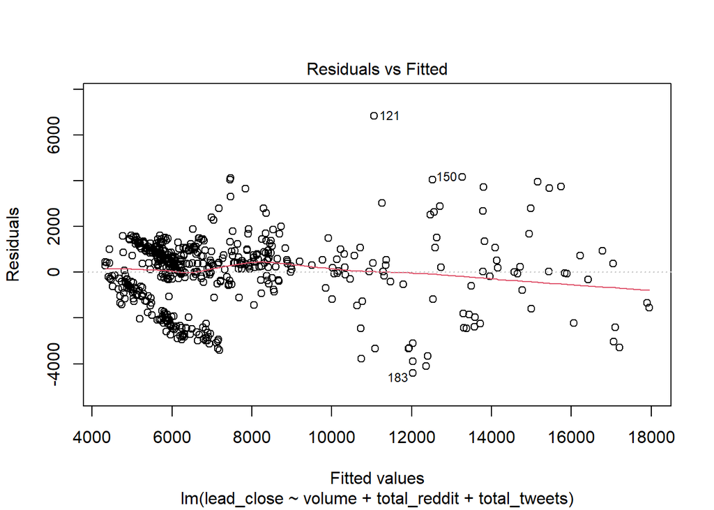

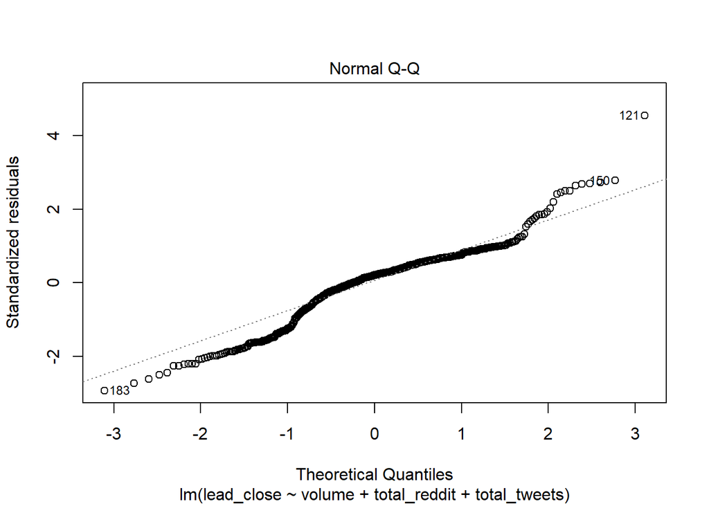

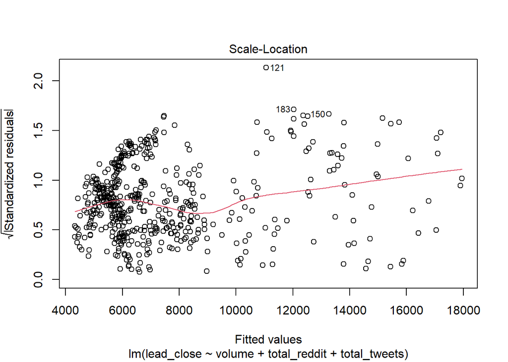

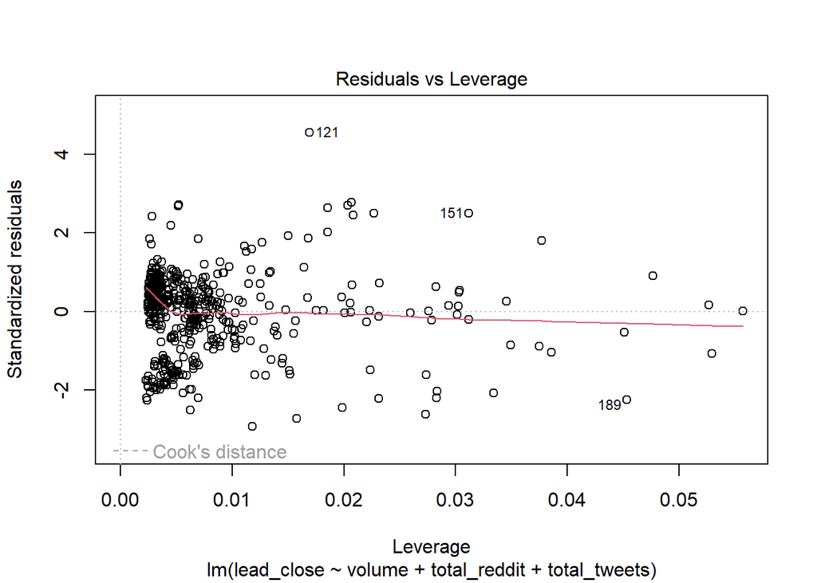

```r
plot(total_models)
```

```r
validate_model(df.daily.all,total_models)
```

```
## [1] 0.7677529
```

```r
durbinWatsonTest(total_models)
```

```
##  lag Autocorrelation D-W Statistic p-value
##    1       0.9320358     0.1293597       0
##  Alternative hypothesis: rho != 0
```

Here, we see the VIF

# Hourly Models

## Simple Linear Regression

In this section, we will perform the same models as above but using the hourly data rather than the daily. The analysis of each model will be the same as above, and will not be elaborated for each model unless a highly succesful model is found.

```r
df.hourly <- mutate_all(data.hourly, ~replace_na(.,0))

df.hourly <- shift_df(data.hourly, 1)[,c('lead_close',
           'positive_reddit',
           'neutral_reddit',
           'negative_reddit',
           'positive_tweets',
           'neutral_tweets',
           'negative_tweets')] %>% agg_lag_df(6)
```

```
## [1] 12356
```

```r
hourly.lin_lin <- lm(lead_close ~ ., data = df.hourly)
summary(hourly.lin_lin)
```

```
##
## Call:
## lm(formula = lead_close ~ ., data = df.hourly)
##
## Residuals:
##      Min       1Q   Median       3Q      Max
## -11253.4  -1382.5     18.2   1086.2  11417.9
##
## Coefficients:
##                   Estimate Std. Error t value Pr(>|t|)
## (Intercept)     3324.58564   43.39838   76.61  < 2e-16 ***
## positive_reddit    2.47444    0.33215    7.45 9.97e-14 ***
## neutral_reddit    16.98598    0.52365   32.44  < 2e-16 ***
## negative_reddit  -13.39168    0.62795  -21.33  < 2e-16 ***
## positive_tweets    1.87832    0.04470   42.02  < 2e-16 ***
## neutral_tweets    -0.20237    0.03030   -6.68 2.49e-11 ***
## negative_tweets   -0.58254    0.05599  -10.40  < 2e-16 ***
## ---
## Signif. codes:  0 '***' 0.001 '**' 0.01 '*' 0.05 '.' 0.1 ' ' 1
##
## Residual standard error: 2090 on 12343 degrees of freedom
## Multiple R-squared:  0.5433, Adjusted R-squared:  0.5431
## F-statistic:  2447 on 6 and 12343 DF,  p-value: < 2.2e-16
```

```r
validate_model(df.hourly, hourly.lin_lin)
```

```
## [1] 0.5416915
```

```r
vif(hourly.lin_lin)
```

```
## positive_reddit  neutral_reddit negative_reddit positive_tweets  neutral_tweets
##       34.008032        8.915185       30.650847       11.463033        7.843070
## negative_tweets
##        7.724495
```

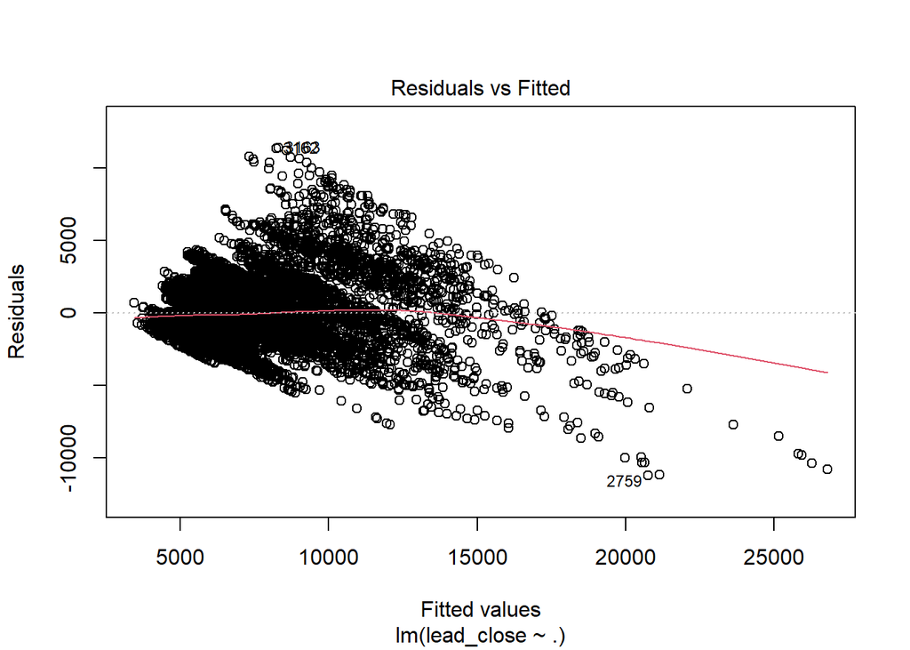

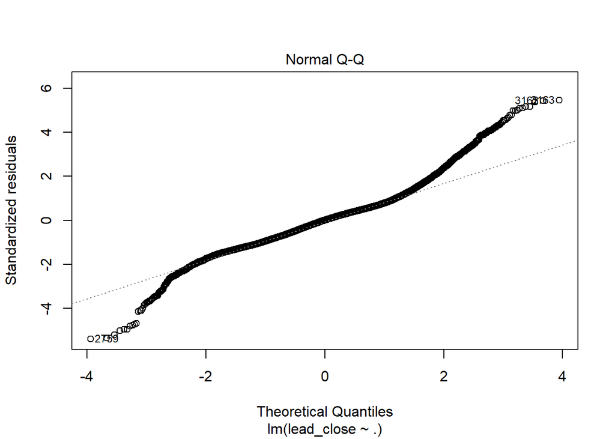

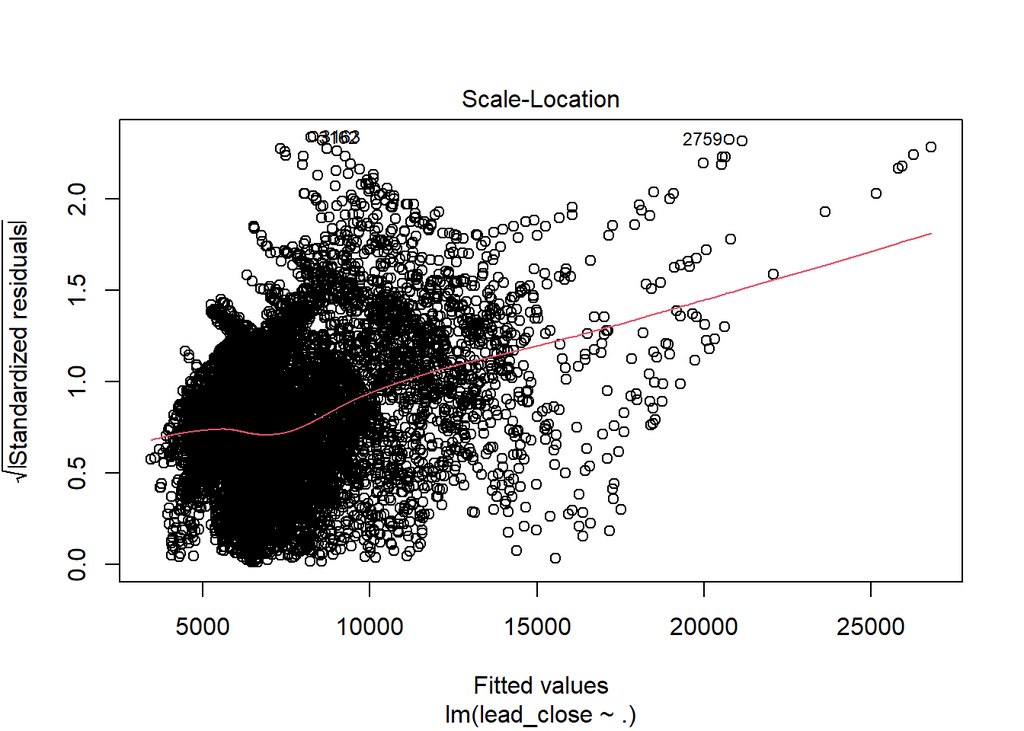

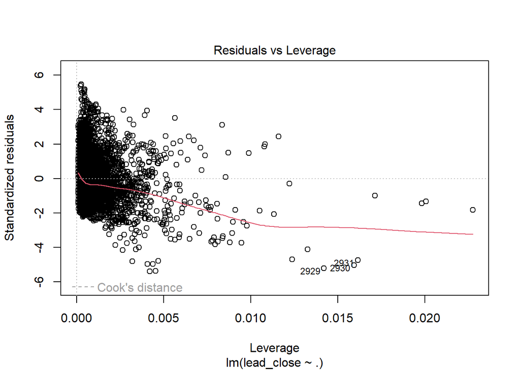

```r
plot(hourly.lin_lin)
```

## Interaction Term

```r
names(data.hourly)[names(data.hourly) == 'volume..btc.'] <- 'volume'
df.hourly <- shift_df(data.hourly, 1)[,c('lead_close',
           'volume',
           'positive_reddit',
           'neutral_reddit',
           'negative_reddit',
           'positive_tweets',
           'neutral_tweets',
           'negative_tweets')] %>% agg_lag_df(6)
```

```
## [1] 12356
```

```r
hourly.lin_lin <- lm(lead_close ~
                         positive_reddit*volume +
                         negative_reddit*volume +
                         neutral_reddit*volume  +
                         positive_tweets*volume +
                         neutral_reddit*volume +
                         negative_tweets*volume, data = df.hourly)
 summary(hourly.lin_lin)
```

```
##
## Call:
## lm(formula = lead_close ~ positive_reddit * volume + negative_reddit *
##     volume + neutral_reddit * volume + positive_tweets * volume +
##     neutral_reddit * volume + negative_tweets * volume, data = df.hourly)
##
## Residuals:
##      Min       1Q   Median       3Q      Max
## -11020.4  -1368.4     31.5   1073.4  11380.7
##
## Coefficients:
##                          Estimate Std. Error t value Pr(>|t|)
## (Intercept)             3.283e+03  4.310e+01  76.189  < 2e-16 ***
## positive_reddit         2.275e+00  3.387e-01   6.718 1.92e-11 ***
## volume                  1.962e-07  1.500e-08  13.077  < 2e-16 ***
## negative_reddit        -1.386e+01  6.501e-01 -21.319  < 2e-16 ***
## neutral_reddit          1.723e+01  5.203e-01  33.115  < 2e-16 ***
## positive_tweets         1.732e+00  3.596e-02  48.150  < 2e-16 ***
## negative_tweets        -6.518e-01  5.562e-02 -11.719  < 2e-16 ***
## positive_reddit:volume  5.034e-10  6.477e-11   7.772 8.31e-15 ***
## volume:negative_reddit  3.966e-11  1.086e-10   0.365    0.715
## volume:neutral_reddit  -1.063e-09  1.840e-10  -5.776 7.83e-09 ***
## volume:positive_tweets -1.253e-10  1.067e-11 -11.741  < 2e-16 ***
## volume:negative_tweets  1.086e-10  1.507e-11   7.209 5.99e-13 ***
## ---
## Signif. codes:  0 '***' 0.001 '**' 0.01 '*' 0.05 '.' 0.1 ' ' 1
##
## Residual standard error: 2064 on 12338 degrees of freedom
## Multiple R-squared:  0.5547, Adjusted R-squared:  0.5543
## F-statistic:  1397 on 11 and 12338 DF,  p-value: < 2.2e-16
```

```r
 vif(hourly.lin_lin)
```

```
## there are higher-order terms (interactions) in this model
## consider setting type = 'predictor'; see ?vif
```

```
##        positive_reddit                 volume        negative_reddit
##              36.251529              12.289512              33.681041
##         neutral_reddit        positive_tweets        negative_tweets
##               9.025764               7.608935               7.814861
## positive_reddit:volume volume:negative_reddit  volume:neutral_reddit
##             340.961198             246.438381             268.420328
## volume:positive_tweets volume:negative_tweets
##             180.160803             107.793719
```

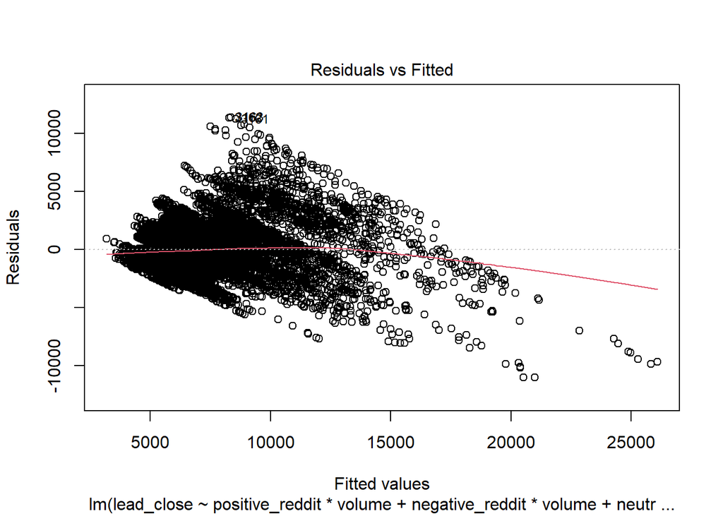

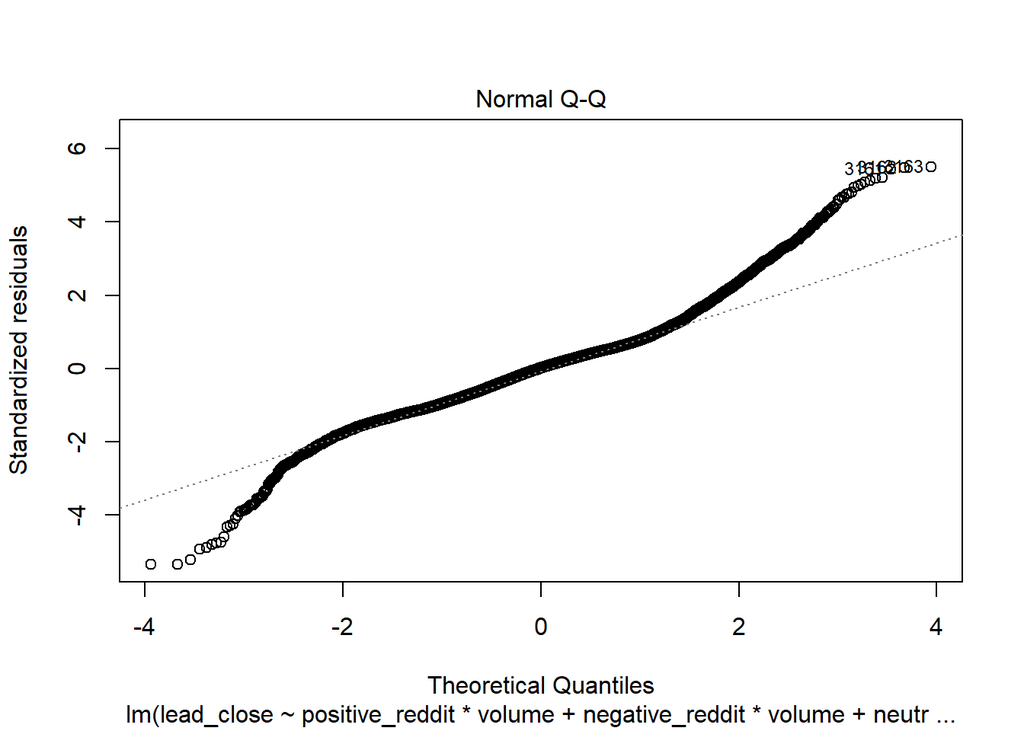

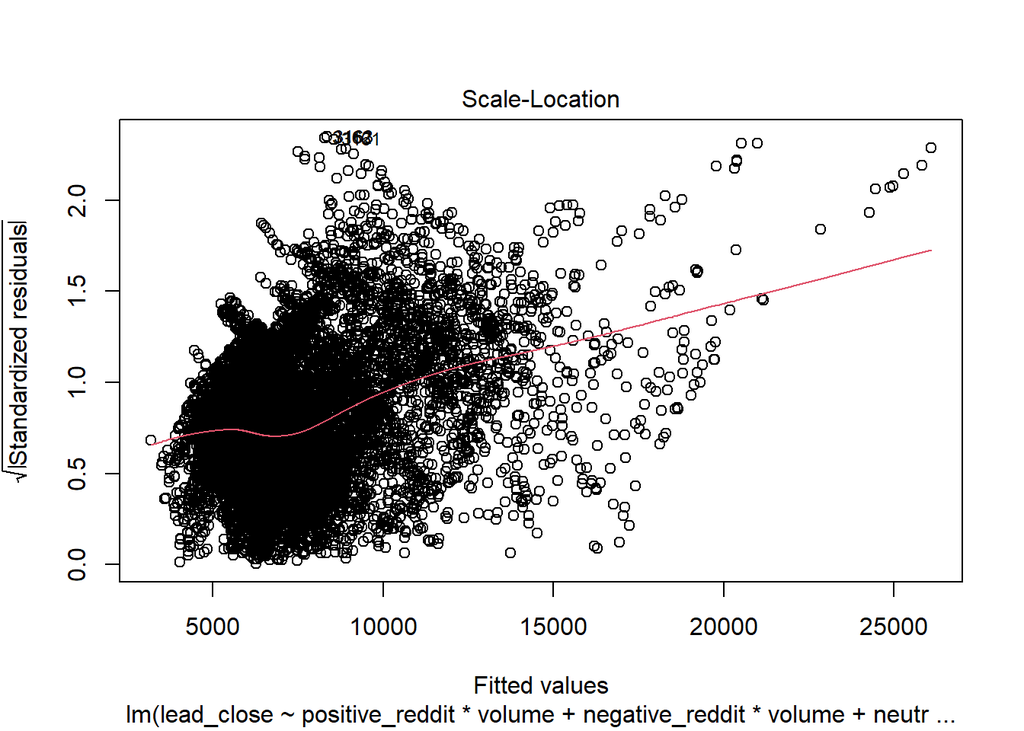

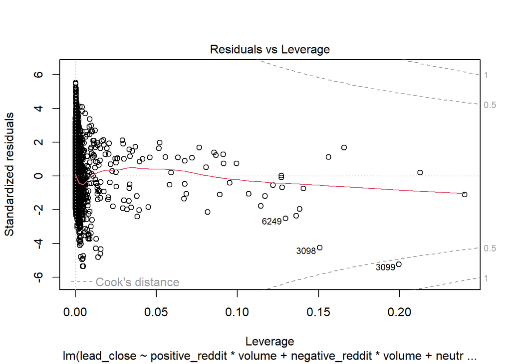

```r
 plot(hourly.lin_lin)
```

## Principal Component Analysis

```r
df.hourly.all <- shift_df(data.hourly, 1)[,c('lead_close',
           'volume',
           'positive_reddit',
           'neutral_reddit',
           'negative_reddit',
           'positive_tweets',
           'neutral_tweets',
           'negative_tweets')] %>% agg_lag_df(6)
```

```
## [1] 12356
```

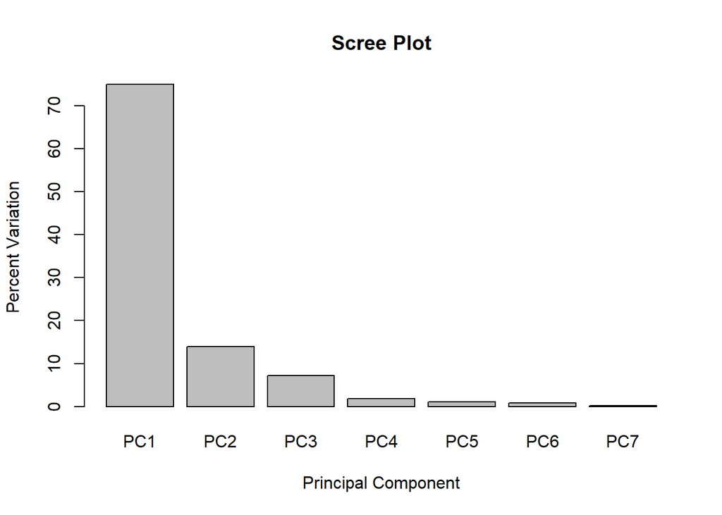

```r
#replace na's with 0
df.hourly.all <- mutate_all(df.hourly.all, ~replace_na(.,0))

#perform PCA
df.hourly.all.pca <- prcomp(~.,df.hourly.all[,!'lead_close'], scale = TRUE)



#scree plot
pca.var.per <- round(summary(df.hourly.all.pca)$importance[2,]*100,1)
barplot(pca.var.per,
         main ="Scree Plot",
         xlab= "Principal Component",
         ylab = "Percent Variation")
```

```r
df.hourly.all.pca.4 <- as.data.frame(cbind(df.hourly.all.pca$x[,1:4],
                                      df.hourly.all[,'lead_close']))

hourly.lin_lin.pca <- lm(lead_close~. ,
                        data = df.hourly.all.pca.4)

summary(hourly.lin_lin.pca)
```

```
##
## Call:
## lm(formula = lead_close ~ ., data = df.hourly.all.pca.4)
##
## Residuals:
##      Min       1Q   Median       3Q      Max
## -10581.0  -1667.4    147.2   1161.9  11423.1
##
## Coefficients:
##             Estimate Std. Error t value Pr(>|t|)
## (Intercept) 7275.466     20.560 353.871   <2e-16 ***
## PC1          882.748      8.974  98.364   <2e-16 ***
## PC2          191.495     20.872   9.175   <2e-16 ***
## PC3          428.972     29.030  14.777   <2e-16 ***
## PC4          985.230     58.076  16.964   <2e-16 ***
## ---
## Signif. codes:  0 '***' 0.001 '**' 0.01 '*' 0.05 '.' 0.1 ' ' 1
##
## Residual standard error: 2285 on 12345 degrees of freedom
## Multiple R-squared:  0.454,  Adjusted R-squared:  0.4538
## F-statistic:  2566 on 4 and 12345 DF,  p-value: < 2.2e-16
```

```r
vif(hourly.lin_lin.pca)
```

```
## PC1 PC2 PC3 PC4
##   1   1   1   1
```

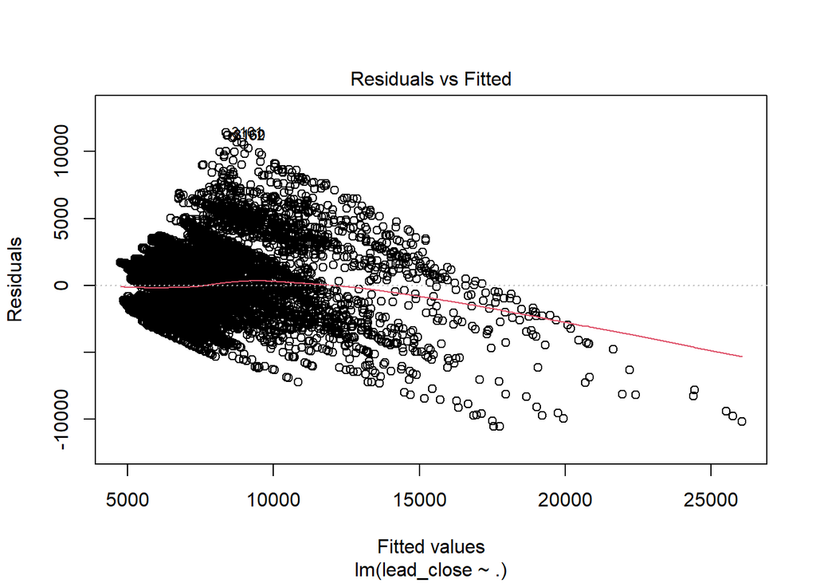

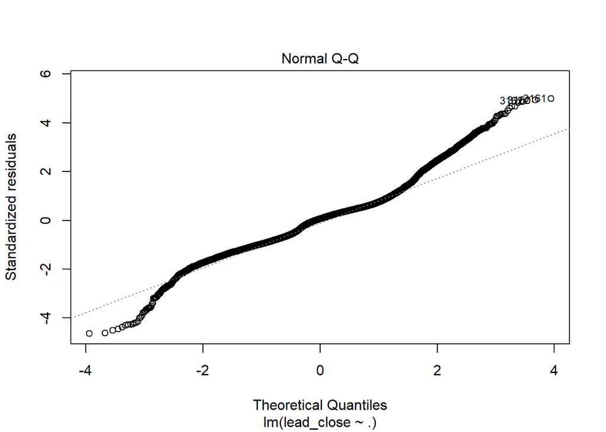

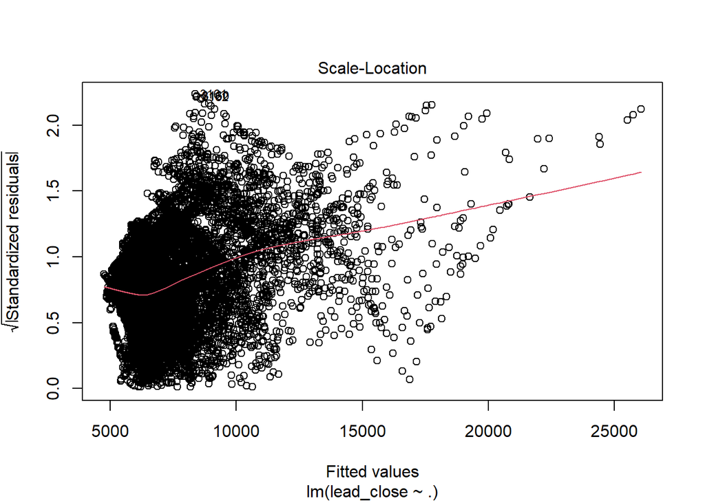

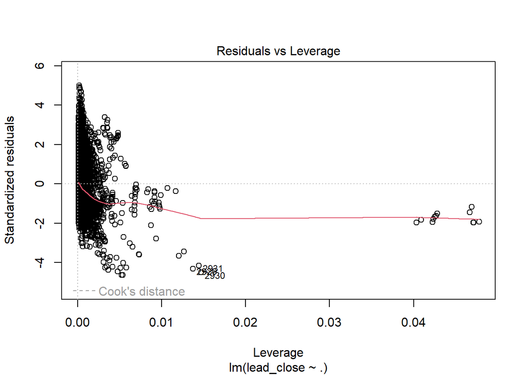

```r
plot(hourly.lin_lin.pca)
```

```r
validate_model(df.hourly.all.pca.4, hourly.lin_lin.pca)
```

```
## [1] 0.4528352
```

## Simple Model - Less Variables

```r
df.hourly.all <- shift_df(data.hourly, 1)[,c('lead_close',
           'volume',
           'total_reddit',
           'total_tweets')] %>% agg_lag_df(6)
```

```
## [1] 12356
```

```r
total_models <- lm(lead_close ~ volume +total_reddit+ total_tweets,
                   df.hourly.all)
vif(total_models)
```

```
##       volume total_reddit total_tweets
##     1.026784     3.122478     3.107713
```

```r
summary(total_models)
```

```
##
## Call:
## lm(formula = lead_close ~ volume + total_reddit + total_tweets,
##     data = df.hourly.all)
##
## Residuals:
##      Min       1Q   Median       3Q      Max
## -12082.1  -1591.5     89.2   1160.8  11722.4
##
## Coefficients:
##               Estimate Std. Error t value Pr(>|t|)
## (Intercept)  3.261e+03  4.749e+01  68.678   <2e-16 ***
## volume       6.398e-08  4.766e-09  13.424   <2e-16 ***
## total_reddit 5.437e-01  6.053e-02   8.982   <2e-16 ***
## total_tweets 4.119e-01  8.393e-03  49.077   <2e-16 ***
## ---
## Signif. codes:  0 '***' 0.001 '**' 0.01 '*' 0.05 '.' 0.1 ' ' 1
##
## Residual standard error: 2268 on 12346 degrees of freedom
## Multiple R-squared:  0.4618, Adjusted R-squared:  0.4617
## F-statistic:  3531 on 3 and 12346 DF,  p-value: < 2.2e-16
```

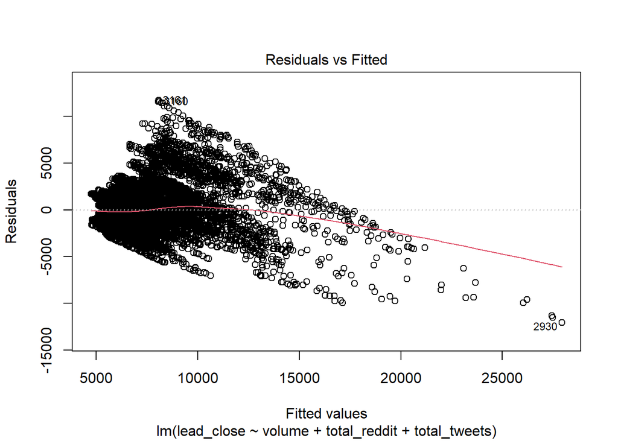

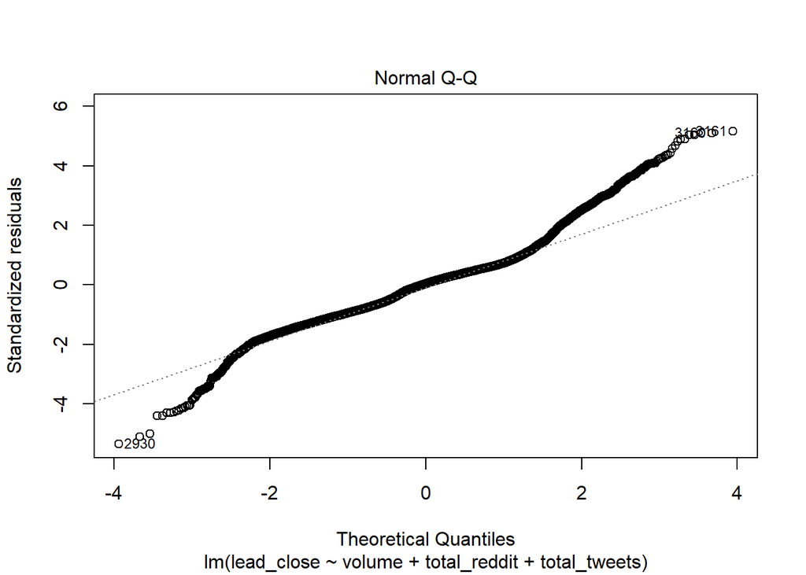

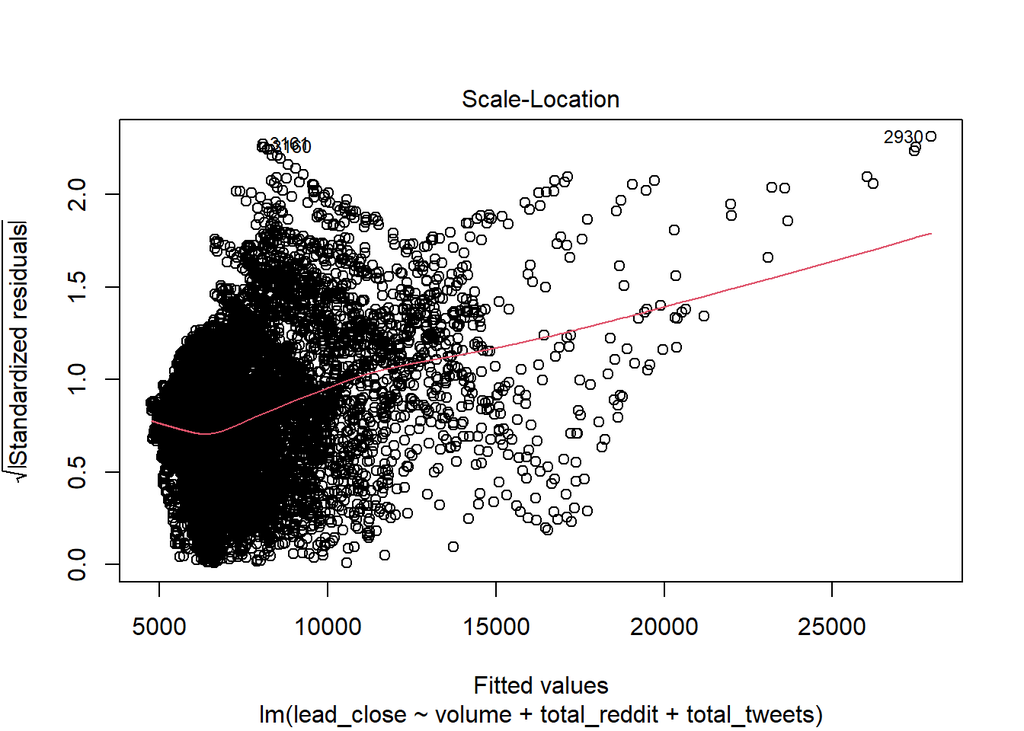

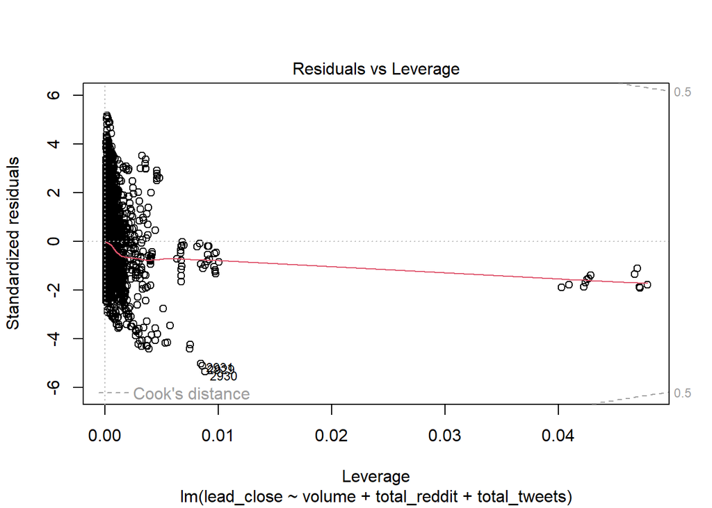

```r
plot(total_models)
```

```r
validate_model(df.hourly.all,total_models)
```

```
## [1] 0.4611665
```

```r
run_intervals <- function(df, form, N){
  r2 <- c()
  for (n in N){
    mdf <- shift_df(df, n)
    m <- lm(formula(form), mdf)

    print(summary(m)$r.squared)
    r2[n] <- summary(m)$r.squared
    r2
  }

}
```

```r
intervals <- run_intervals(data.daily,
              form = 'log(lead_close) ~ volume +total_reddit+ total_tweets',
              N = c(1,12,18,24))
```

```
## [1] 0.5539864
## [1] 0.5106468
## [1] 0.4757888
## [1] 0.4465255
```